# assignment4 - Copy (6) - Copy

## Assignment 4

This assignment asks you to use resources at hand to apply module 6 - Linear Regression to several sets of data.

## Learning Outcomes

- Exploratory analysis for regression
- Understand difference between linear and non-linear models
- Carry out OLS regression model
- Evaluate model

**Question 1**

- For each data set in Assignment4_linear_regression_data.xlsx:
- Create a scatter plot and visually decide if a linear model is appropriate (a matrix scatter plot will would be most efficient).
- If the relation is not linear, transform the data accordingly.
  - Try logarithm, exponential, square root, square, etc., for Y and/or X until you see a linear relation. You only need to report what is the transformation chosen, not all the attempts. Note: most of the time, you can guess visually. A systematic way is to create a matrix scatter plot of the different transformations. A generic way we did not cover is to use a Box-Cox transformation.
- Create an OLS model for the original and transformed data if required.
  - Evaluate if the OLS assumptions are met: normality of errors centered around zero, equal variance, etc..., for the original data and transformed data if appropriate.
  - Comment how the transformation impacted the different assumptions. (This should be done only by looking at the output diagnostic charts created by the software)
  - If datasets have outliers, remove the outliers and see the effect in the model (slope, intercept and R-square)

The output of the assignment should be:

- OLS full report for the original and transformed data if appropriate (only two datasets should need transformation).
- A short comment on the validity of the linear assumptions for the original and transformed data set when appropriate (it should not need to be longer than a couple of sentences).
- An interpretation of the slope and intercept in relation to the original data, i.e. if the model is linear [intercept value] is the expected value when the independent variable is zero, etc.). If the model is not linear, you need to transform the equation back to its original form.

Check out the following if you need further guidance: http://www.bzst.com/2009/09/interpreting-log-transformed-variables.html

https://stats.idre.ucla.edu/other/mult-pkg/faq/general/faqhow-do-i-interpret-a-regression-model-when-some-variables-are-log-transformed/

https://stats.idre.ucla.edu/sas/faq/how-can-i-interpret-log-transformed-variables-in-terms-of-percent-change-in-linear-regression/

https://stats.stackexchange.com/questions/266722/interpretation-of-linear-regression-results-where-dependent-variable-is-transfor

- If the dataset have outliers, determine if the outlier have leverage or not by comparing the OLS with and without the outlier.

```python
#Thomas Tang
```

```python
pip install statsmodels
```

```python
#import numpy as np # linear algebra
#import pandas as pd # data processing, CSV file I/O (e.g. pd.read_csv)
#from scipy.stats import ks_2samp
import matplotlib as plt
import matplotlib.pyplot as plt
import os
import re


# Import the libraries first
import numpy as np
import pandas as pd

# We will use matplotlib to plot figures
import matplotlib.pyplot as plt

# For regression analysis we will use the statsmodels package
import statsmodels.formula.api as sm

# For visual inspection of the regression models
from statsmodels.graphics.regressionplots import plot_regress_exog, plot_fit, plot_leverage_resid2, influence_plot



for dirname, _, filenames in os.walk('./'):
    for filename in filenames:
        if (filename == "Assignment4_linear_regresion_data.xlsx"):
          print(os.path.join(dirname, filename))
```

```
./Assignment4_linear_regresion_data.xlsx
```

```python
df1 = pd.read_excel("Assignment4_linear_regresion_data.xlsx", sheet_name="Set 1")  #open file to read data
df2 = pd.read_excel("Assignment4_linear_regresion_data.xlsx", sheet_name="Set 2")  #open file to read data
df3 = pd.read_excel("Assignment4_linear_regresion_data.xlsx", sheet_name="Set 3")  #open file to read data
df4 = pd.read_excel("Assignment4_linear_regresion_data.xlsx", sheet_name="Set 4")  #open file to read data
df5 = pd.read_excel("Assignment4_linear_regresion_data.xlsx", sheet_name="Set 5")  #open file to read data
df6 = pd.read_excel("Assignment4_linear_regresion_data.xlsx", sheet_name="Set 6")  #open file to read data

#change header label upper case to lower case: "Y" to "y" on all sheets
df1.columns = map(str.lower, df1.columns)
df2.columns = map(str.lower, df2.columns)
df3.columns = map(str.lower, df3.columns)
df4.columns = map(str.lower, df4.columns)
df5.columns = map(str.lower, df5.columns)
df6.columns = map(str.lower, df6.columns)

df1.set_index('y')                        #set index using PassengerId as unique primary key
df2.set_index('y')
df3.set_index('y')
df4.set_index('y')
df5.set_index('y')
df6.set_index('y')

df1.head()                                  #display data layout with examples on top rows
df2.head()
df3.head()
df4.head()
df5.head()
df6.head()
df3.head()
```

|  | y | x |
| --- | --- | --- |
| 0 | 6428.915770 | 9.517 |
| 1 | 2640.000728 | 5.113 |
| 2 | 12858.599267 | 9.773 |
| 3 | 5491.450053 | 8.428 |
| 4 | 2838.820108 | 5.752 |

```
          y         x
y  1.000000  0.989468
x  0.989468  1.000000
```

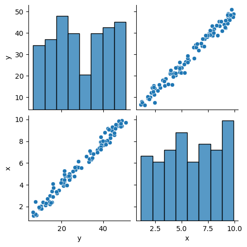

```python
#We look at numeric variables to see if there is a correlation
import seaborn as sns

print(df1.corr())
g = sns.pairplot(df1.sample(len(df1['y'])))
```

```
          y         x
y  1.000000  0.745168
x  0.745168  1.000000
```

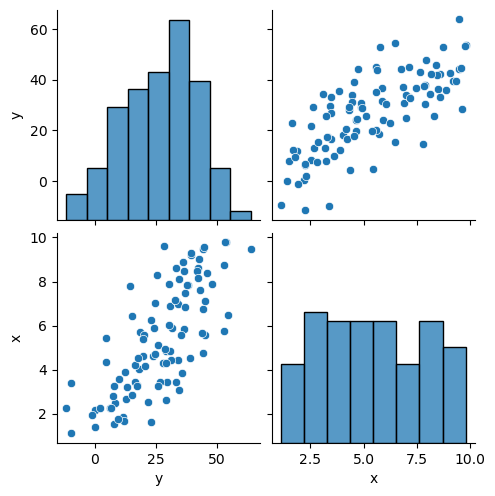

```python
print(df2.corr())
g = sns.pairplot(df2.sample(len(df2['y'])))
```

```
          y         x
y  1.000000  0.869031
x  0.869031  1.000000
```

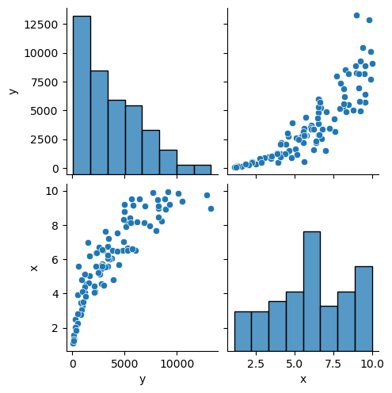

```python
print(df3.corr())
g = sns.pairplot(df3.sample(len(df3['y'])))
```

```
          y         x
y  1.000000  0.616155
x  0.616155  1.000000
```

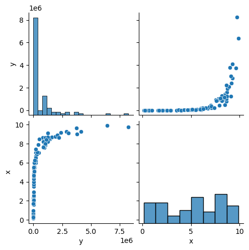

```python
print(df4.corr())
g = sns.pairplot(df4.sample(len(df4['y'])))
```

```
          y         x
y  1.000000  0.897892
x  0.897892  1.000000
```

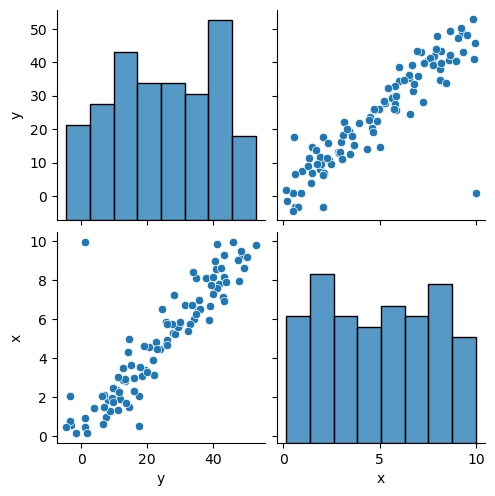

```python
print(df5.corr())
g = sns.pairplot(df5.sample(len(df5['y'])))
```

```
          y         x
y  1.000000  0.955578
x  0.955578  1.000000
```

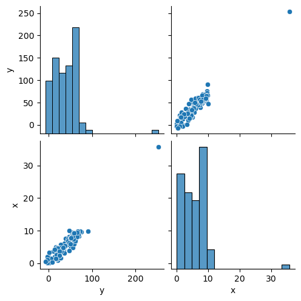

```python
print(df6.corr())
g = sns.pairplot(df6.sample(len(df6['y'])))
```

```python
# From above plottings, it is seen the relation is not linear on:
# dataset: 3
# dataset: 4
# transform the data accordingly.

# Outlier on:
# dataset: 5
# dataset: 6
```

```python
df3.describe()
```

|  | y | x |
| --- | --- | --- |
| count | 100.000000 | 100.000000 |
| mean | 3853.843519 | 5.999130 |
| std | 3042.522716 | 2.444058 |
| min | 85.816012 | 1.095000 |
| 25% | 1255.307962 | 4.307500 |
| 50% | 3190.568047 | 6.214000 |
| 75% | 5633.938126 | 8.110000 |
| max | 13259.109970 | 9.958000 |

```python
#############################################################################
# For non-linear models, transformation using Box-Cox
#############################################################################
from scipy import stats as st

y_transformed_df3, lmbda_df3 = st.boxcox(df3['y'])
y_transformed_df4, lmbda_df4 = st.boxcox(df4['y'])

print (y_transformed_df3)
print (lmbda_df3)
print (y_transformed_df4)
print (lmbda_df4)
```

[output not shown]

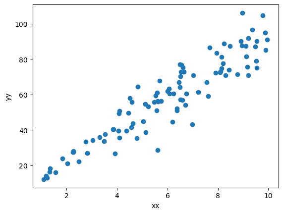

```
         yy       xx
yy  1.00000  0.93141
xx  0.93141  1.00000
```

|  | yy | xx |
| --- | --- | --- |
| 0 | 78.994369 | 9.517 |
| 1 | 54.763335 | 5.113 |
| 2 | 104.769880 | 9.773 |
| 3 | 74.057879 | 8.428 |
| 4 | 56.435874 | 5.752 |
| ... | ... | ... |
| 95 | 72.663186 | 8.091 |
| 96 | 16.320093 | 1.325 |
| 97 | 49.668245 | 4.446 |
| 98 | 18.357036 | 1.335 |
| 99 | 55.891360 | 4.587 |

100 rows × 2 columns

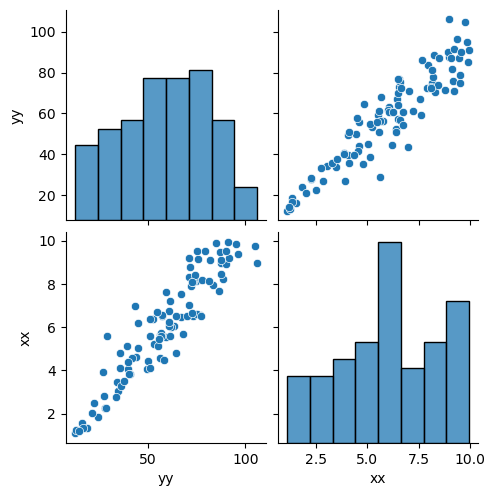

```python
#############################################################################
# After Box-Cox transformation, we plot again... (for df3)
#############################################################################
#create new dataframe df3_, with headers yy,xx
df3_ = pd.DataFrame(columns=['yy', 'xx'])

df3_['xx'] =  df3['x']
df3_['yy'] = y_transformed_df3
plt.plot(df3_.xx, df3_.yy, 'o')

plt.xlabel('xx')
plt.ylabel('yy')
plt.show()

print(df3_.corr())
g = sns.pairplot(df3_.sample(len(df3_['yy'])))

df3_
```

```python
# Let's calculate the Pearson's correlation coefficient first

# This will calculate the correlation matrix
cm = df3_.corr(method = 'pearson')

# Print correlation matrix
cm
```

|  | yy | xx |
| --- | --- | --- |
| yy | 1.00000 | 0.93141 |
| xx | 0.93141 | 1.00000 |

```python
# Calculate the means of xx, yy
mu_xx = np.mean(df3_.xx)
mu_yy = np.mean(df3_.yy)

print(mu_xx, mu_yy)
```

```
5.999130000000001 58.071316635003
```

```python
# Calculate the standard deviations of x, y
sig_xx = np.std(df3_.xx, ddof=1)
sig_yy = np.std(df3_.yy, ddof=1 )

print(sig_xx, sig_yy)
```

```
2.44405810762231 22.88912296027125
```

```python
beta_1 = sig_yy/sig_xx * cm.loc['xx', 'yy']
beta_0 = mu_yy - beta_1 * mu_xx

print(beta_0, beta_1)
```

```
5.741774392659124 8.722855187726198
```

```python
# Initialize the regression model  #----------------before Linear
m_0 = sm.ols('y ~ x', data = df3)
m_0 = m_0.fit()
m_0.summary()
```

OLS Regression Results

| Dep. Variable: | y | R-squared: | 0.755 |
| --- | --- | --- | --- |
| Model: | OLS | Adj. R-squared: | 0.753 |
| Method: | Least Squares | F-statistic: | 302.4 |
| Date: | Wed, 10 Apr 2024 | Prob (F-statistic): | 1.04e-31 |
| Time: | 21:47:05 | Log-Likelihood: | -873.07 |
| No. Observations: | 100 | AIC: | 1750. |
| Df Residuals: | 98 | BIC: | 1755. |
| Df Model: | 1 |  |  |
| Covariance Type: | nonrobust |  |  |

|  | coef | std err | t | P>\|t\| | [0.025 | 0.975] |
| --- | --- | --- | --- | --- | --- | --- |
| Intercept | -2636.1748 | 402.741 | -6.546 | 0.000 | -3435.400 | -1836.949 |
| x | 1081.8266 | 62.216 | 17.388 | 0.000 | 958.361 | 1205.292 |

| Omnibus: | 21.170 | Durbin-Watson: | 2.159 |
| --- | --- | --- | --- |
| Prob(Omnibus): | 0.000 | Jarque-Bera (JB): | 37.896 |
| Skew: | 0.863 | Prob(JB): | 5.90e-09 |
| Kurtosis: | 5.474 | Cond. No. | 17.6 |

Notes:  
[1] Standard Errors assume that the covariance matrix of the errors is correctly specified.

```python
# Initialize the regression model # ----------------after linear
m = sm.ols('yy ~ xx', data = df3_)
```

```python
# Fit the regression model
m = m.fit()
```

```python
# Let's take a look at the regression parameters
m.params
```

```
Intercept    5.741774
xx           8.722855
dtype: float64
```

```python
# Calculate estimates of yy
intercept, slope = m.params
df3_['y_est'] = intercept + slope * df3_.xx
```

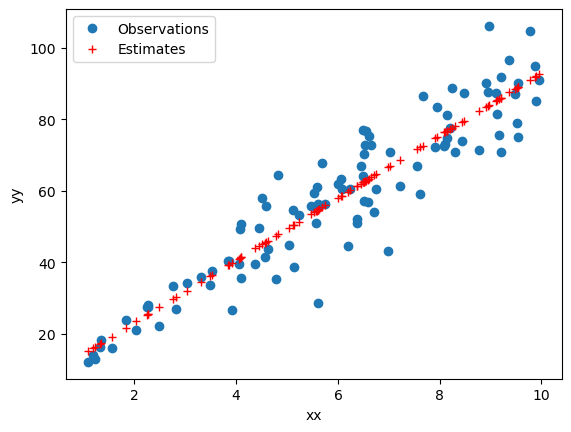

```python
# Let's plot the estimates along the actual observations
plt.plot(df3_.xx, df3_.yy, 'o', label = 'Observations')
plt.xlabel('xx')
plt.ylabel('yy')

# Draw estimates
plt.plot(df3_.xx, df3_.y_est, 'r+', label='Estimates')

# Add legend
plt.legend()
plt.show()
```

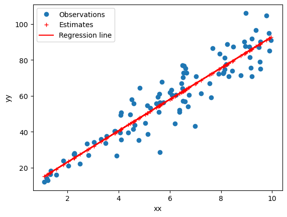

```python
# As you may notice, all the estimates lie on the line;
# this is the regression line

plt.plot(df3_.xx, df3_.yy, 'o', label = 'Observations')
plt.xlabel('xx')
plt.ylabel('yy')

# Draw estimates
plt.plot(df3_.xx, df3_.y_est, 'r+', label='Estimates')

# Plot regression line
plt.plot(df3_.xx, df3_.y_est, 'r-', label='Regression line')

# Add legend
plt.legend()
plt.show()
```

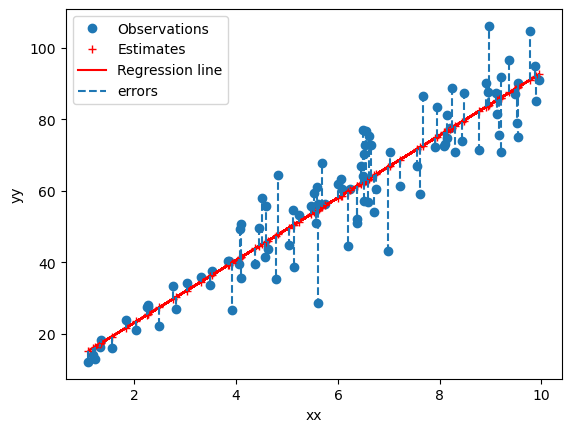

```python
# We can even depict the errors associated with individual observations

plt.plot(df3_.xx, df3_.yy, 'o', label = 'Observations')
plt.xlabel('xx')
plt.ylabel('yy')

# Draw estimates
plt.plot(df3_.xx, df3_.y_est, 'r+', label='Estimates')

# Plot regression line
plt.plot(df3_.xx, df3_.y_est, 'r-', label='Regression line')

# Plot errors
plt.vlines(df3_.xx, df3_.y_est, df3_.yy, linestyles='dashed', label = 'errors')

# Add legend
plt.legend()
plt.show()
```

```python
# Show the model summary
m.summary()
```

OLS Regression Results

| Dep. Variable: | yy | R-squared: | 0.868 |
| --- | --- | --- | --- |
| Model: | OLS | Adj. R-squared: | 0.866 |
| Method: | Least Squares | F-statistic: | 641.8 |
| Date: | Wed, 10 Apr 2024 | Prob (F-statistic): | 8.32e-45 |
| Time: | 21:47:06 | Log-Likelihood: | -353.39 |
| No. Observations: | 100 | AIC: | 710.8 |
| Df Residuals: | 98 | BIC: | 716.0 |
| Df Model: | 1 |  |  |
| Covariance Type: | nonrobust |  |  |

|  | coef | std err | t | P>\|t\| | [0.025 | 0.975] |
| --- | --- | --- | --- | --- | --- | --- |
| Intercept | 5.7418 | 2.229 | 2.576 | 0.011 | 1.319 | 10.165 |
| xx | 8.7229 | 0.344 | 25.333 | 0.000 | 8.040 | 9.406 |

| Omnibus: | 3.044 | Durbin-Watson: | 1.854 |
| --- | --- | --- | --- |
| Prob(Omnibus): | 0.218 | Jarque-Bera (JB): | 2.483 |
| Skew: | -0.254 | Prob(JB): | 0.289 |
| Kurtosis: | 3.582 | Cond. No. | 17.6 |

Notes:  
[1] Standard Errors assume that the covariance matrix of the errors is correctly specified.

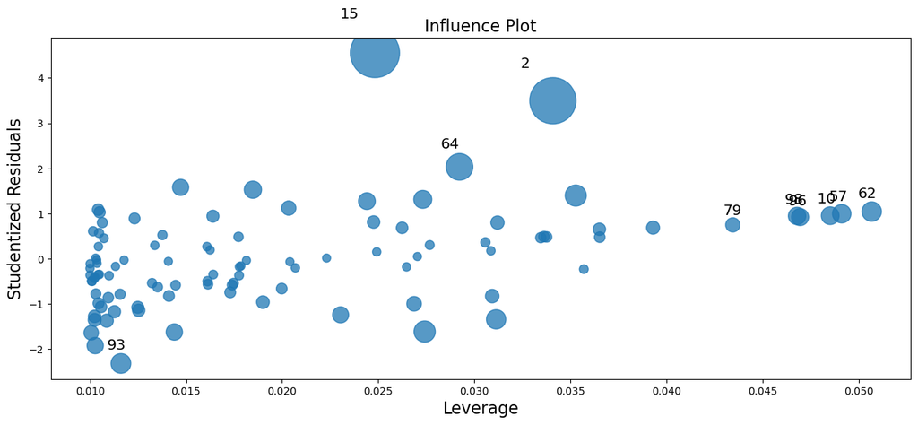

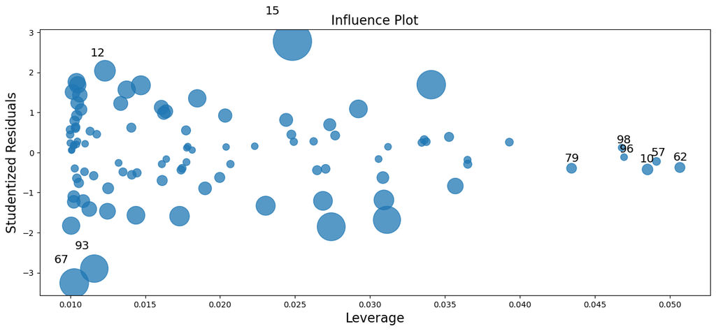

```python
fig, ax = plt.subplots(figsize=(15,6))
fig = influence_plot(m_0, ax=ax)
fig, ax = plt.subplots(figsize=(15,6))
fig = influence_plot(m, ax=ax)
```

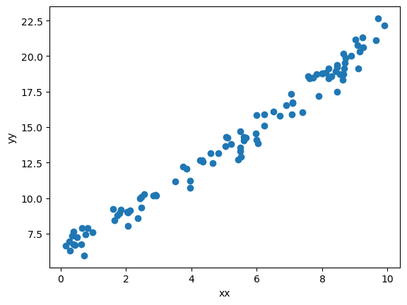

```
          yy        xx
yy  1.000000  0.989315
xx  0.989315  1.000000
```

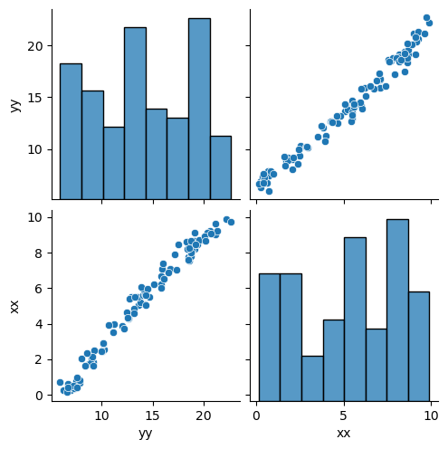

```python
#############################################################################
# After Box-Cox transformation, we plot again...(for df4)
#############################################################################
df4_ = pd.DataFrame(columns=['yy', 'xx'])

df4_['xx'] =  df4['x']
df4_['yy'] = y_transformed_df4
plt.plot(df4_.xx, df4_.yy, 'o')

plt.xlabel('xx')
plt.ylabel('yy')
plt.show()

print(df4_.corr())
g = sns.pairplot(df4_.sample(len(df4_['yy'])))
```

```
          yy        xx
yy  1.000000  0.989315
xx  0.989315  1.000000
5.227871 14.014783226310286
2.9860725563821755 4.66995245770154
5.9262195982961 1.5472003092681867
                            OLS Regression Results
==============================================================================
Dep. Variable:                      y   R-squared:                       0.380
Model:                            OLS   Adj. R-squared:                  0.373
Method:                 Least Squares   F-statistic:                     59.97
Date:                Wed, 10 Apr 2024   Prob (F-statistic):           8.87e-12
Time:                        21:47:07   Log-Likelihood:                -1526.2
No. Observations:                 100   AIC:                             3056.
Df Residuals:                      98   BIC:                             3062.
Df Model:                           1
Covariance Type:            nonrobust
==============================================================================
                 coef    std err          t      P>|t|      [0.025      0.975]
------------------------------------------------------------------------------
Intercept  -7.535e+05    2.1e+05     -3.585      0.001   -1.17e+06   -3.36e+05
x           2.707e+05   3.49e+04      7.744      0.000    2.01e+05     3.4e+05
==============================================================================
Omnibus:                      102.143   Durbin-Watson:                   2.077
Prob(Omnibus):                  0.000   Jarque-Bera (JB):             1253.666
Skew:                           3.381   Prob(JB):                    5.89e-273
Kurtosis:                      18.973   Cond. No.                         12.4
==============================================================================

Notes:
[1] Standard Errors assume that the covariance matrix of the errors is correctly specified.
Intercept    5.92622
xx           1.54720
dtype: float64
```

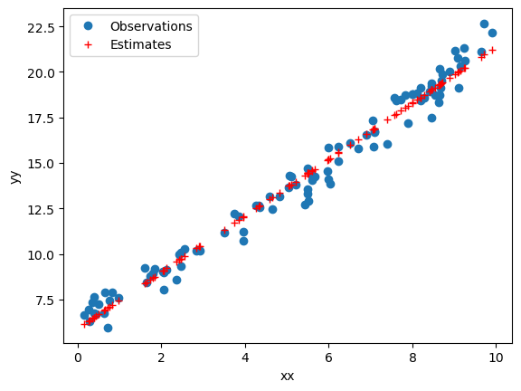

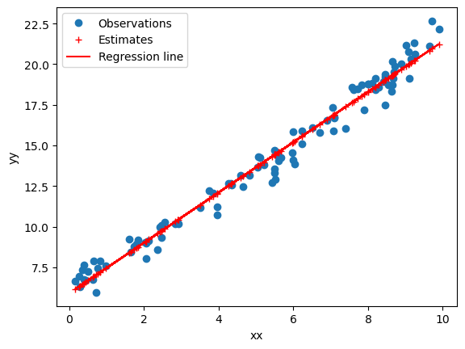

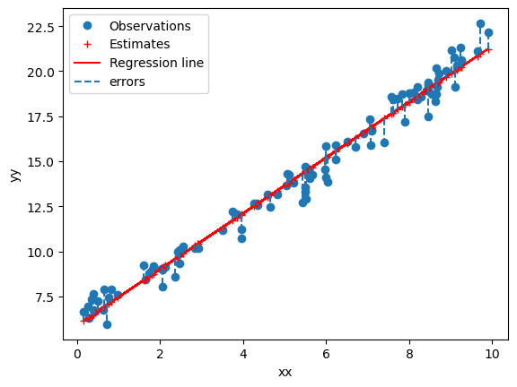

```
                            OLS Regression Results
==============================================================================
Dep. Variable:                     yy   R-squared:                       0.979
Model:                            OLS   Adj. R-squared:                  0.979
Method:                 Least Squares   F-statistic:                     4512.
Date:                Wed, 10 Apr 2024   Prob (F-statistic):           9.06e-84
Time:                        21:47:08   Log-Likelihood:                -102.95
No. Observations:                 100   AIC:                             209.9
Df Residuals:                      98   BIC:                             215.1
Df Model:                           1
Covariance Type:            nonrobust
==============================================================================
                 coef    std err          t      P>|t|      [0.025      0.975]
------------------------------------------------------------------------------
Intercept      5.9262      0.138     42.789      0.000       5.651       6.201
xx             1.5472      0.023     67.174      0.000       1.501       1.593
==============================================================================
Omnibus:                        2.768   Durbin-Watson:                   2.185
Prob(Omnibus):                  0.251   Jarque-Bera (JB):                2.703
Skew:                          -0.394   Prob(JB):                        0.259
Kurtosis:                       2.833   Cond. No.                         12.4
==============================================================================

Notes:
[1] Standard Errors assume that the covariance matrix of the errors is correctly specified.
```

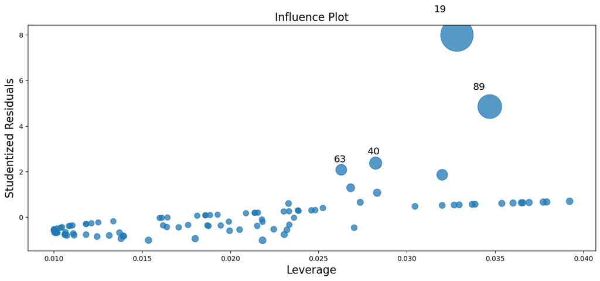

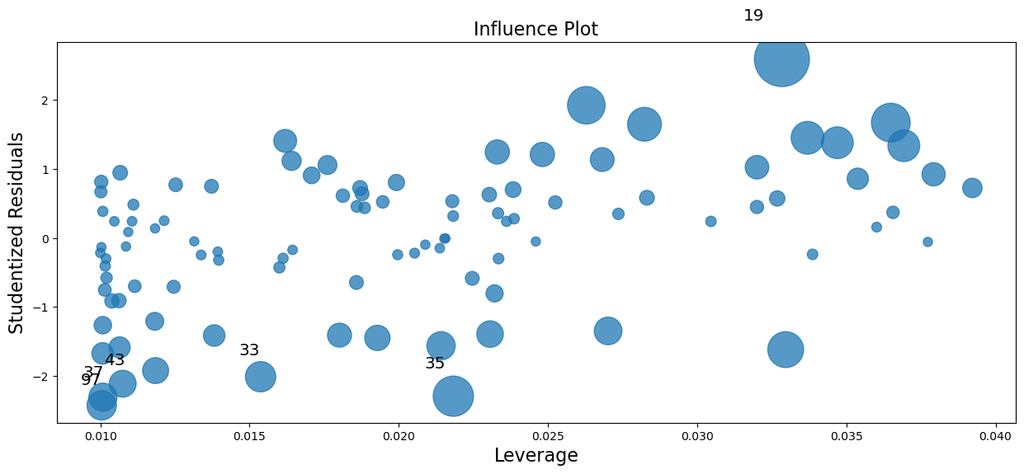

```python
# Let's calculate the Pearson's correlation coefficient first
# This will calculate the correlation matrix
cm = df4_.corr(method = 'pearson')
print (cm) # Print correlation matrix

# Calculate the means of xx, yy
mu_xx = np.mean(df4_.xx)
mu_yy = np.mean(df4_.yy)
print(mu_xx, mu_yy)

# Calculate the standard deviations of x, y
sig_xx = np.std(df4_.xx, ddof=1)
sig_yy = np.std(df4_.yy, ddof=1 )
print(sig_xx, sig_yy)

beta_1 = sig_yy/sig_xx * cm.loc['xx', 'yy']
beta_0 = mu_yy - beta_1 * mu_xx
print(beta_0, beta_1)

# Initialize the regression model  #----------------before Linear
m_0 = sm.ols('y ~ x', data = df4)
m_0 = m_0.fit()
print (m_0.summary())

# Initialize the regression model # ----------------after linear
m = sm.ols('yy ~ xx', data = df4_)
m = m.fit()               # Fit the regression model
print (m.params)          # Let's take a look at the regression parameters

# Calculate estimates of y
intercept, slope = m.params
df4_['y_est'] = intercept + slope * df4_.xx

# Let's plot the estimates along the actual observations
plt.plot(df4_.xx, df4_.yy, 'o', label = 'Observations')
plt.xlabel('xx')
plt.ylabel('yy')

# Draw estimates
plt.plot(df4_.xx, df4_.y_est, 'r+', label='Estimates')

# Add legend
plt.legend()
plt.show()

# As you may notice, all the estimates lie on the line;
# this is the regression line
plt.plot(df4_.xx, df4_.yy, 'o', label = 'Observations')
plt.xlabel('xx')
plt.ylabel('yy')

# Draw estimates
plt.plot(df4_.xx, df4_.y_est, 'r+', label='Estimates')

# Plot regression line
plt.plot(df4_.xx, df4_.y_est, 'r-', label='Regression line')

# Add legend
plt.legend()
plt.show()

#--------------------------------------------------------------------------
# We can even depict the errors associated with individual observations
plt.plot(df4_.xx, df4_.yy, 'o', label = 'Observations')
plt.xlabel('xx')
plt.ylabel('yy')

# Draw estimates
plt.plot(df4_.xx, df4_.y_est, 'r+', label='Estimates')

# Plot regression line
plt.plot(df4_.xx, df4_.y_est, 'r-', label='Regression line')

# Plot errors
plt.vlines(df4_.xx, df4_.y_est, df4_.yy, linestyles='dashed', label = 'errors')

# Add legend
plt.legend()
plt.show()

#-------------------------------------------------------------------------
# Show the model summary
print (m.summary())

#-------------------------------------------------------------------------
fig, ax = plt.subplots(figsize=(15,6))
fig = influence_plot(m_0, ax=ax)

fig, ax = plt.subplots(figsize=(15,6))
fig = influence_plot(m, ax=ax)
```

```
          y         x
y  1.000000  0.897892
x  0.897892  1.000000
```

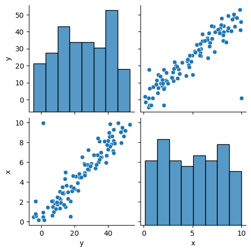

```python
#############################################################################
#df5 (with outliner)
#############################################################################
print(df5.corr())
g = sns.pairplot(df5.sample(len(df5['y'])))
```

```
          y         x
y  1.000000  0.951897
x  0.951897  1.000000
```

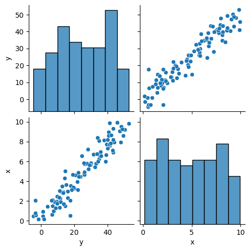

```python
#df5, excluded outliner, at last row (row#102)

df5_ = df5[:len(df5['y'])-1]
df5_.tail()
print(df5_.corr())
g = sns.pairplot(df5_.sample(len(df5_['y'])-1))
```

```python
# Initialize the regression model  #----------------before (with outlier)

m_0 = sm.ols('y ~ x', data = df5)
m_0 = m_0.fit()
print (m_0.summary())
```

```
                            OLS Regression Results
==============================================================================
Dep. Variable:                      y   R-squared:                       0.806
Model:                            OLS   Adj. R-squared:                  0.804
Method:                 Least Squares   F-statistic:                     411.9
Date:                Wed, 10 Apr 2024   Prob (F-statistic):           4.70e-37
Time:                        21:47:11   Log-Likelihood:                -334.42
No. Observations:                 101   AIC:                             672.8
Df Residuals:                      99   BIC:                             678.1
Df Model:                           1
Covariance Type:            nonrobust
==============================================================================
                 coef    std err          t      P>|t|      [0.025      0.975]
------------------------------------------------------------------------------
Intercept      0.9213      1.346      0.685      0.495      -1.749       3.591
x              4.7671      0.235     20.294      0.000       4.301       5.233
==============================================================================
Omnibus:                      113.783   Durbin-Watson:                   1.491
Prob(Omnibus):                  0.000   Jarque-Bera (JB):             2578.951
Skew:                          -3.591   Prob(JB):                         0.00
Kurtosis:                      26.691   Cond. No.                         11.8
==============================================================================

Notes:
[1] Standard Errors assume that the covariance matrix of the errors is correctly specified.
```

```python
# Initialize the regression model  #----------------after (removed outlier)

m = sm.ols('y ~ x', data = df5_)
m = m.fit()

#print (m.params)
#intercept, slope = m.params
#print (intercept, slope)

print (m.summary())
```

```
                            OLS Regression Results
==============================================================================
Dep. Variable:                      y   R-squared:                       0.906
Model:                            OLS   Adj. R-squared:                  0.905
Method:                 Least Squares   F-statistic:                     945.8
Date:                Wed, 10 Apr 2024   Prob (F-statistic):           3.84e-52
Time:                        21:47:12   Log-Likelihood:                -294.13
No. Observations:                 100   AIC:                             592.3
Df Residuals:                      98   BIC:                             597.5
Df Model:                           1
Covariance Type:            nonrobust
==============================================================================
                 coef    std err          t      P>|t|      [0.025      0.975]
------------------------------------------------------------------------------
Intercept     -0.0993      0.935     -0.106      0.916      -1.954       1.756
x              5.0705      0.165     30.753      0.000       4.743       5.398
==============================================================================
Omnibus:                        3.022   Durbin-Watson:                   1.918
Prob(Omnibus):                  0.221   Jarque-Bera (JB):                2.760
Skew:                          -0.158   Prob(JB):                        0.252
Kurtosis:                       3.750   Cond. No.                         11.7
==============================================================================

Notes:
[1] Standard Errors assume that the covariance matrix of the errors is correctly specified.
```

```python
# df5: Comparison before and after outlier removal.
#    R-square:    0.806 vs 0.906    (rises after outlier removal)
#    intercept:   0.9213 vs -0.0993 (drops after outlier removal)
#    slope:       4.7671 vs 5.0705  (rises after outlier removal)
```

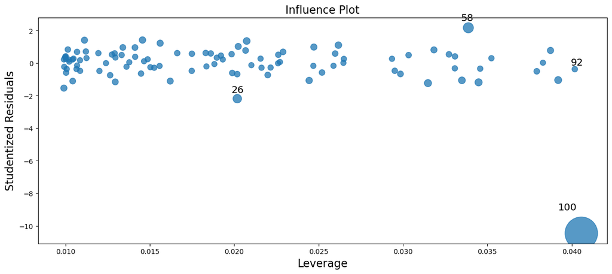

```python
fig, ax = plt.subplots(figsize=(15,6))
fig = influence_plot(m_0, ax=ax)
```

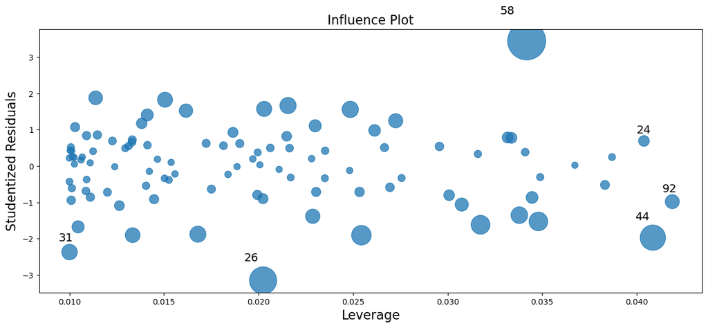

```python
fig, ax = plt.subplots(figsize=(15,6))
fig = influence_plot(m, ax=ax)
```

```
          y         x
y  1.000000  0.955578
x  0.955578  1.000000
```

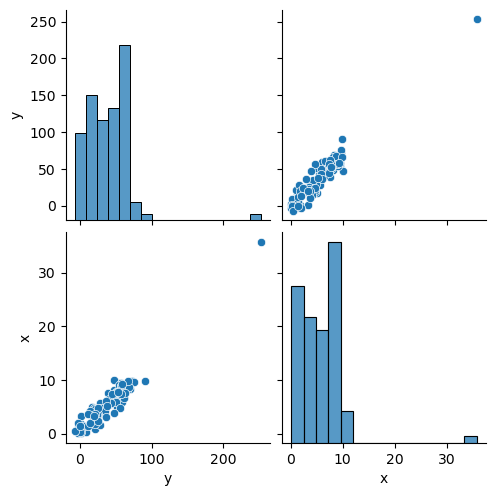

```python
#############################################################################
#df6 (with outliner)
#############################################################################
print(df6.corr())
g = sns.pairplot(df6.sample(len(df6['y'])))
```

```
            y       x
95  57.886726  7.6842
96  56.695106  8.7167
97  70.342334  9.6165
98  20.791865  1.7477
99  59.018123  8.3886
          y         x
y  1.000000  0.914794
x  0.914794  1.000000
```

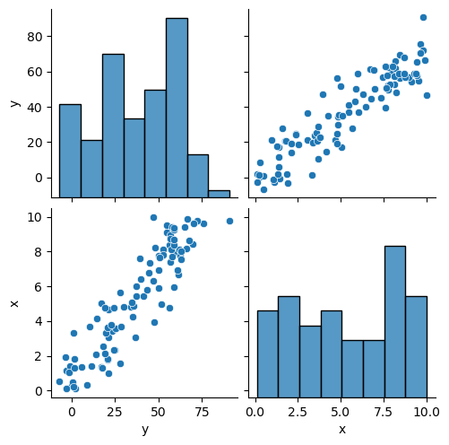

```python
#df6, excluded outliner, at last row (row#102)
df6_ = df6[:len(df6['y'])-1]
print (df6_.tail())
print(df6_.corr())
g = sns.pairplot(df6_.sample(len(df6_['y'])-1))
```

```python
# Initialize the regression model  #----------------before (with outlier)
m_0_df6 = sm.ols('y ~ x', data = df6)
m_0_df6 = m_0_df6.fit()
print (m_0_df6.summary())
```

```
                            OLS Regression Results
==============================================================================
Dep. Variable:                      y   R-squared:                       0.913
Model:                            OLS   Adj. R-squared:                  0.912
Method:                 Least Squares   F-statistic:                     1041.
Date:                Wed, 10 Apr 2024   Prob (F-statistic):           2.49e-54
Time:                        21:47:14   Log-Likelihood:                -367.52
No. Observations:                 101   AIC:                             739.0
Df Residuals:                      99   BIC:                             744.3
Df Model:                           1
Covariance Type:            nonrobust
==============================================================================
                 coef    std err          t      P>|t|      [0.025      0.975]
------------------------------------------------------------------------------
Intercept     -0.3059      1.534     -0.199      0.842      -3.350       2.739
x              7.0272      0.218     32.259      0.000       6.595       7.459
==============================================================================
Omnibus:                        0.494   Durbin-Watson:                   2.255
Prob(Omnibus):                  0.781   Jarque-Bera (JB):                0.262
Skew:                           0.120   Prob(JB):                        0.877
Kurtosis:                       3.070   Cond. No.                         11.8
==============================================================================

Notes:
[1] Standard Errors assume that the covariance matrix of the errors is correctly specified.
```

```python
# Initialize the regression model  #----------------after (removed outlier)
m_1_df6 = sm.ols('y ~ x', data = df6_)
m_1_df6 = m_1_df6.fit()

#print (m.params)
#intercept, slope = m.params
#print (intercept, slope)

print (m_1_df6.summary())
```

```
                            OLS Regression Results
==============================================================================
Dep. Variable:                      y   R-squared:                       0.837
Model:                            OLS   Adj. R-squared:                  0.835
Method:                 Least Squares   F-statistic:                     502.7
Date:                Wed, 10 Apr 2024   Prob (F-statistic):           2.29e-40
Time:                        21:47:14   Log-Likelihood:                -364.34
No. Observations:                 100   AIC:                             732.7
Df Residuals:                      98   BIC:                             737.9
Df Model:                           1
Covariance Type:            nonrobust
==============================================================================
                 coef    std err          t      P>|t|      [0.025      0.975]
------------------------------------------------------------------------------
Intercept     -0.0203      1.899     -0.011      0.991      -3.788       3.748
x              6.9703      0.311     22.420      0.000       6.353       7.587
==============================================================================
Omnibus:                        0.459   Durbin-Watson:                   2.259
Prob(Omnibus):                  0.795   Jarque-Bera (JB):                0.261
Skew:                           0.123   Prob(JB):                        0.877
Kurtosis:                       3.044   Cond. No.                         12.7
==============================================================================

Notes:
[1] Standard Errors assume that the covariance matrix of the errors is correctly specified.
```

```python
# df6: Comparison before and after outlier removal.
#    R-square:     0.913 vs 0.837    (drops after outlier removal)
#    intercept:   -0.3059 vs -0.0203 (rises after outlier removal)
#    slope:        7.02772 vs 6.9703  (drops after outlier removal)


# df5 and df6 had opposite results on rises/drops on R-Square, intercept, slope after outlier removal.
```

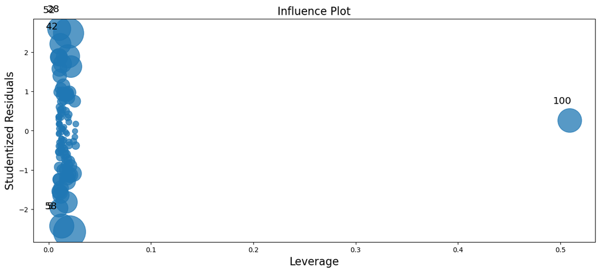

```python
fig, ax = plt.subplots(figsize=(15,6))
fig = influence_plot(m_0_df6, ax=ax)
```

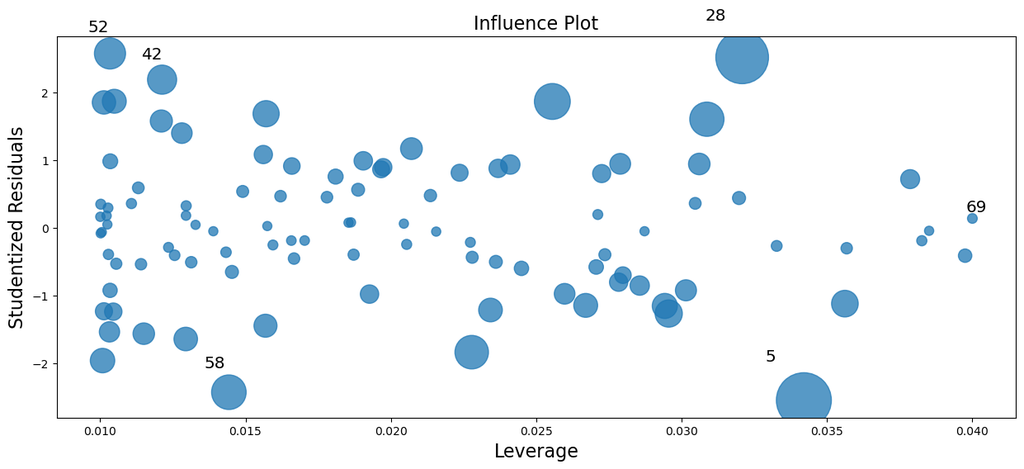

```python
fig, ax = plt.subplots(figsize=(15,6))
fig = influence_plot(m_1_df6, ax=ax)
```